# White Wines Exploration by Diego Valdivieso

The goal of this report is to explore the white wine’s dataset to determine which chemical properties influence the quality.

# Univariate Plots Section

```
## 'data.frame':    4898 obs. of  12 variables:
##  $ fixed.acidity       : num  7 6.3 8.1 7.2 7.2 8.1 6.2 7 6.3 8.1 ...
##  $ volatile.acidity    : num  0.27 0.3 0.28 0.23 0.23 0.28 0.32 0.27 0.3 0.22 ...
##  $ citric.acid         : num  0.36 0.34 0.4 0.32 0.32 0.4 0.16 0.36 0.34 0.43 ...
##  $ residual.sugar      : num  20.7 1.6 6.9 8.5 8.5 6.9 7 20.7 1.6 1.5 ...
##  $ chlorides           : num  0.045 0.049 0.05 0.058 0.058 0.05 0.045 0.045 0.049 0.044 ...
##  $ free.sulfur.dioxide : num  45 14 30 47 47 30 30 45 14 28 ...
##  $ total.sulfur.dioxide: num  170 132 97 186 186 97 136 170 132 129 ...
##  $ density             : num  1.001 0.994 0.995 0.996 0.996 ...
##  $ pH                  : num  3 3.3 3.26 3.19 3.19 3.26 3.18 3 3.3 3.22 ...
##  $ sulphates           : num  0.45 0.49 0.44 0.4 0.4 0.44 0.47 0.45 0.49 0.45 ...
##  $ alcohol             : num  8.8 9.5 10.1 9.9 9.9 10.1 9.6 8.8 9.5 11 ...
##  $ quality             : Ord.factor w/ 7 levels "3"<"4"<"5"<"6"<..: 4 4 4 4 4 4 4 4 4 4 ...
```

```
##  fixed.acidity    volatile.acidity  citric.acid     residual.sugar
##  Min.   : 3.800   Min.   :0.0800   Min.   :0.0000   Min.   : 0.600
##  1st Qu.: 6.300   1st Qu.:0.2100   1st Qu.:0.2700   1st Qu.: 1.700
##  Median : 6.800   Median :0.2600   Median :0.3200   Median : 5.200
##  Mean   : 6.855   Mean   :0.2782   Mean   :0.3342   Mean   : 6.391
##  3rd Qu.: 7.300   3rd Qu.:0.3200   3rd Qu.:0.3900   3rd Qu.: 9.900
##  Max.   :14.200   Max.   :1.1000   Max.   :1.6600   Max.   :65.800
##
##    chlorides       free.sulfur.dioxide total.sulfur.dioxide
##  Min.   :0.00900   Min.   :  2.00      Min.   :  9.0
##  1st Qu.:0.03600   1st Qu.: 23.00      1st Qu.:108.0
##  Median :0.04300   Median : 34.00      Median :134.0
##  Mean   :0.04577   Mean   : 35.31      Mean   :138.4
##  3rd Qu.:0.05000   3rd Qu.: 46.00      3rd Qu.:167.0
##  Max.   :0.34600   Max.   :289.00      Max.   :440.0
##
##     density             pH          sulphates         alcohol
##  Min.   :0.9871   Min.   :2.720   Min.   :0.2200   Min.   : 8.00
##  1st Qu.:0.9917   1st Qu.:3.090   1st Qu.:0.4100   1st Qu.: 9.50
##  Median :0.9937   Median :3.180   Median :0.4700   Median :10.40
##  Mean   :0.9940   Mean   :3.188   Mean   :0.4898   Mean   :10.51
##  3rd Qu.:0.9961   3rd Qu.:3.280   3rd Qu.:0.5500   3rd Qu.:11.40
##  Max.   :1.0390   Max.   :3.820   Max.   :1.0800   Max.   :14.20
##
##  quality
##  3:  20
##  4: 163
##  5:1457
##  6:2198
##  7: 880
##  8: 175
##  9:   5
```

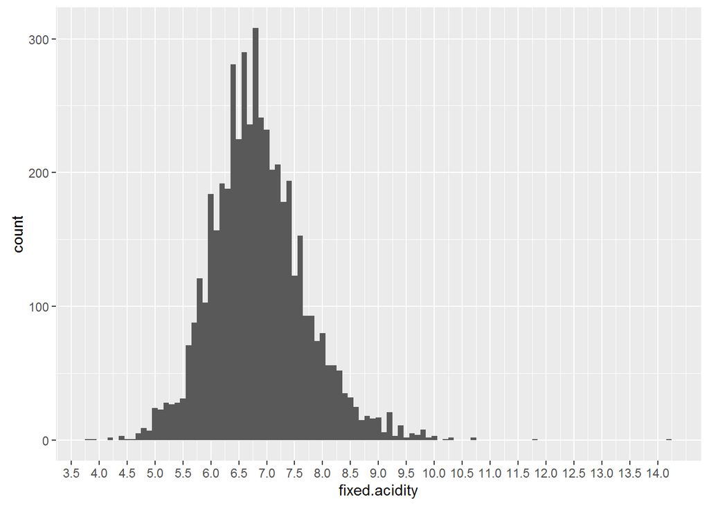

```
##    Min. 1st Qu.  Median    Mean 3rd Qu.    Max.
##   3.800   6.300   6.800   6.855   7.300  14.200
```

Most wines’ fixed acidity lies between 6 and 8 with a peak around 7. The distribution is approximately normal with many outliers to the right.

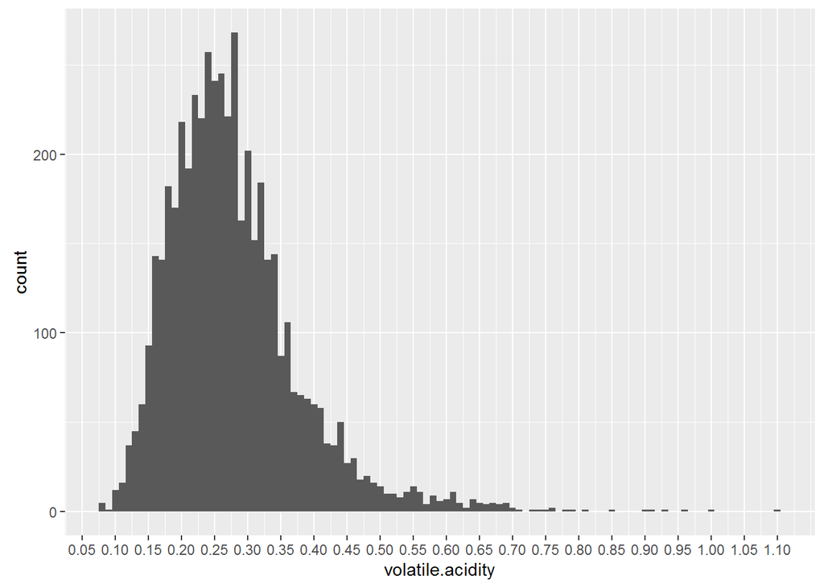

```
##    Min. 1st Qu.  Median    Mean 3rd Qu.    Max.
##  0.0800  0.2100  0.2600  0.2782  0.3200  1.1000
```

Most wines volatile acidity lies between 0.2 and 0.4. The distribution is roughly normal, but a bit right skewed. Again many outlier to the right.

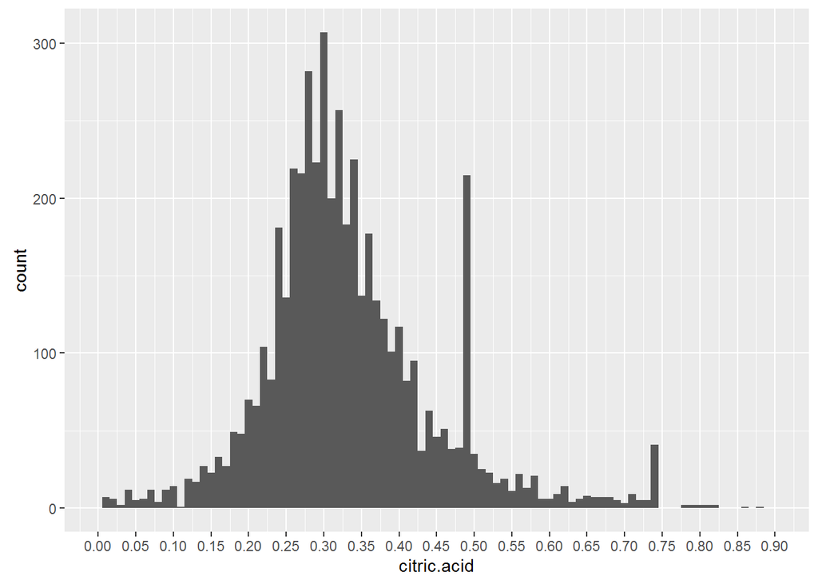

```
##    Min. 1st Qu.  Median    Mean 3rd Qu.    Max.
##  0.0000  0.2700  0.3200  0.3342  0.3900  1.6600
```

The distribution is approximately normal but there is a striking peak close to 0.5. I wonder why this peak is placed at that particular value… There are multiples outliers to the right as in the last two plots.

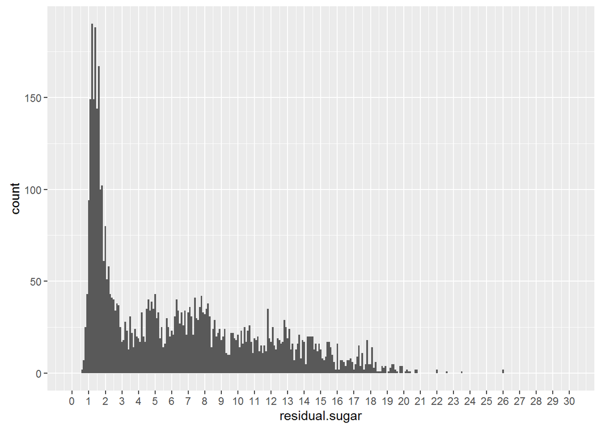

```
##    Min. 1st Qu.  Median    Mean 3rd Qu.    Max.
##   0.600   1.700   5.200   6.391   9.900  65.800
```

Very different from the previous variables distribution. It is notorious how the highest wine counts are placed around two and then the number decreases drastically to the right.

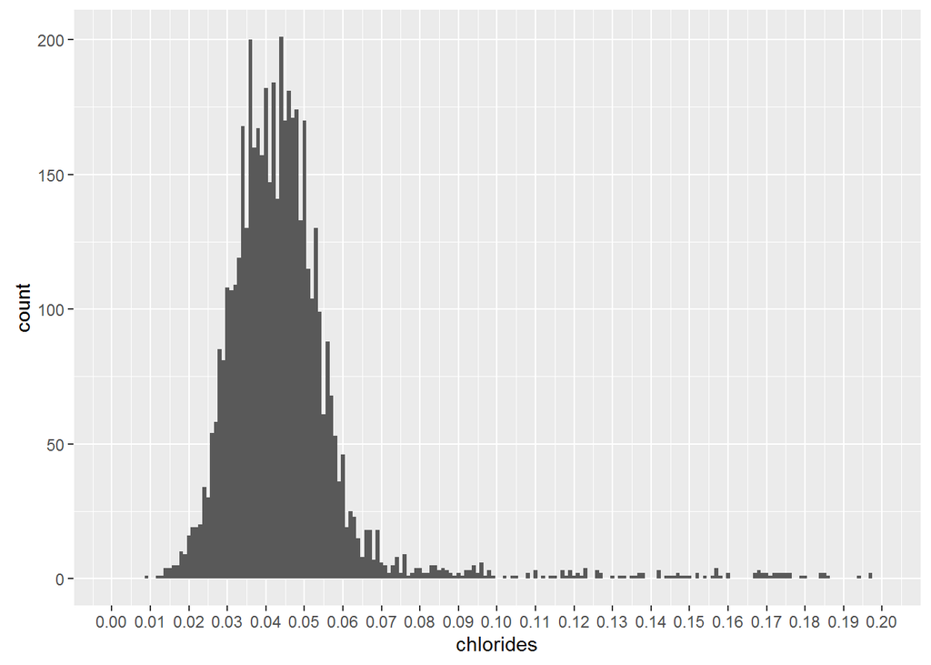

```
##    Min. 1st Qu.  Median    Mean 3rd Qu.    Max.
## 0.00900 0.03600 0.04300 0.04577 0.05000 0.34600
```

It is again roughly normal, with multiples outliers to the right.

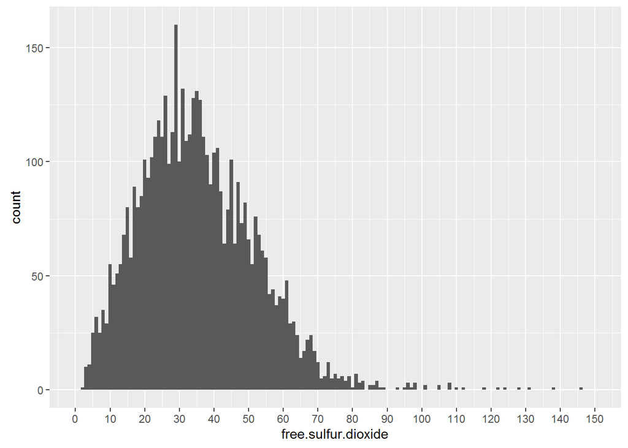

```
##    Min. 1st Qu.  Median    Mean 3rd Qu.    Max.
##    2.00   23.00   34.00   35.31   46.00  289.00
```

Roughly normal, with a salient peak around 30, which is a bit striking because the frequency for this peak is around 25 greater than the following peak.

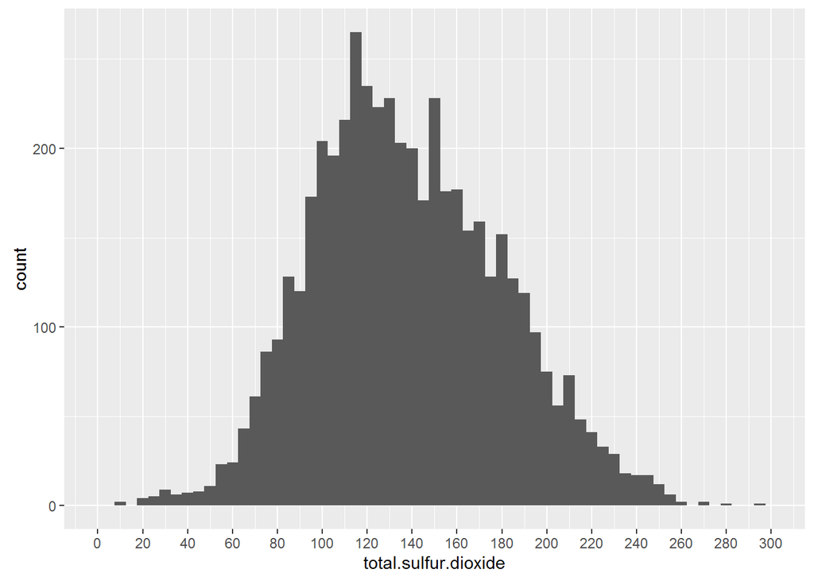

```
##    Min. 1st Qu.  Median    Mean 3rd Qu.    Max.
##     9.0   108.0   134.0   138.4   167.0   440.0
```

Distribution approximately normal with a peak around 120.

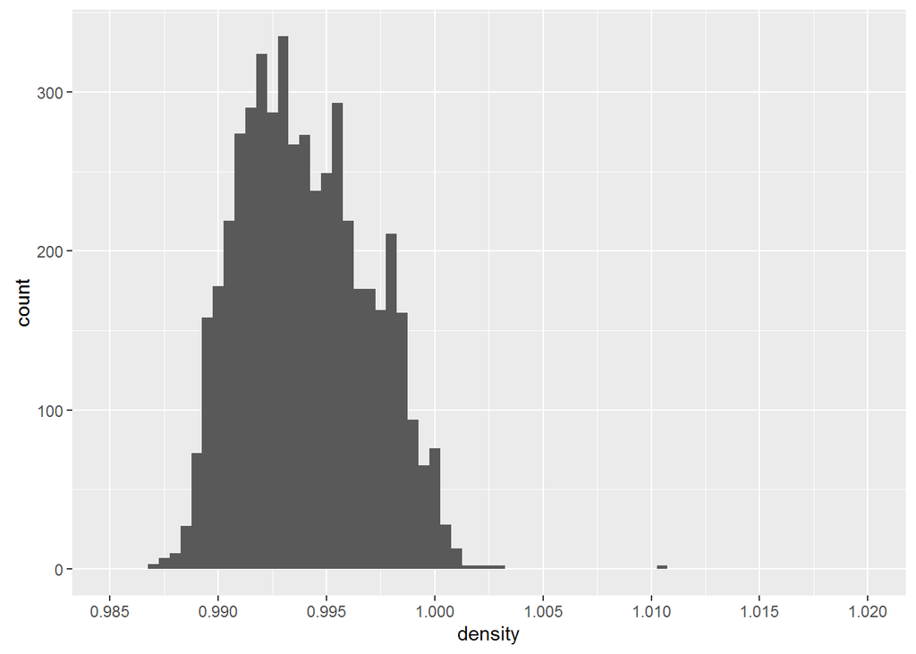

```
##    Min. 1st Qu.  Median    Mean 3rd Qu.    Max.
##  0.9871  0.9917  0.9937  0.9940  0.9961  1.0390
```

Again distribution tends to be normal and many outliers to the right. The peak is around 0.9925

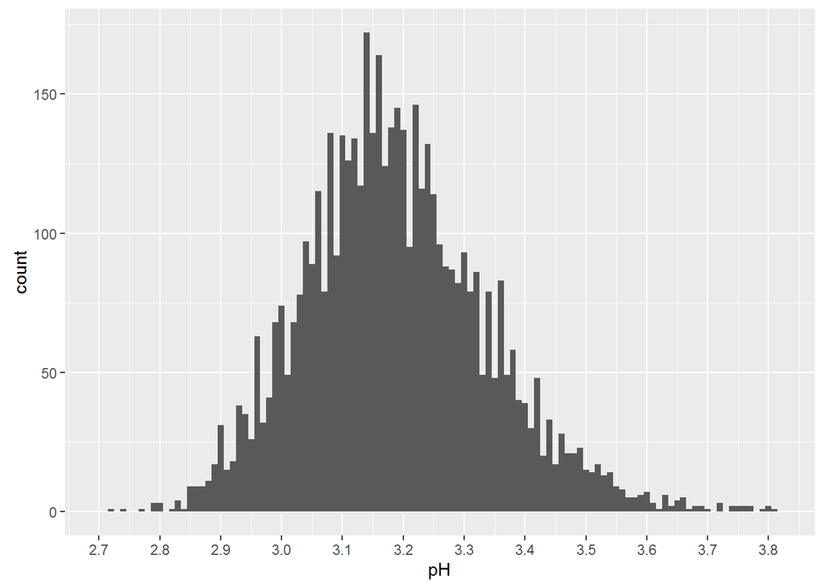

```
##    Min. 1st Qu.  Median    Mean 3rd Qu.    Max.
##   2.720   3.090   3.180   3.188   3.280   3.820
```

It is the distribution closest to the normal one I’ve seen so far. And also one of the few without striking outliers.

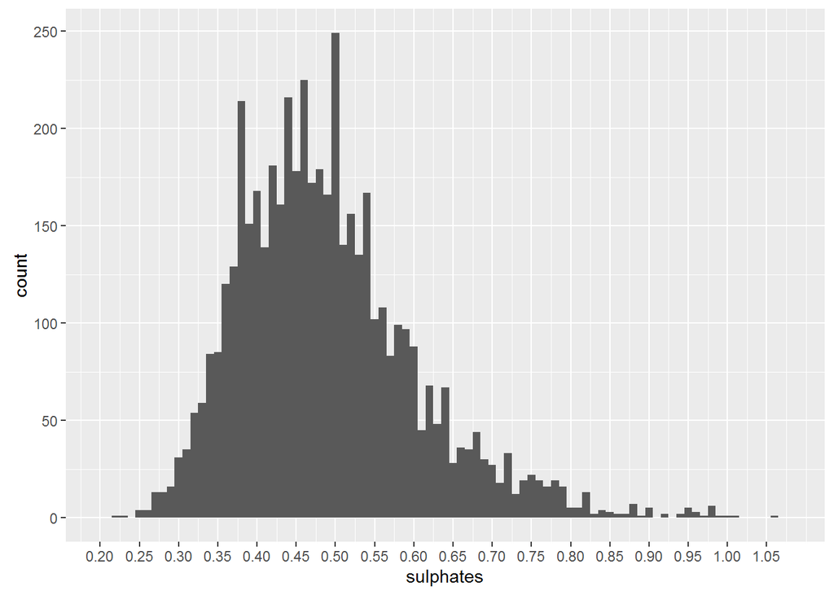

```
##    Min. 1st Qu.  Median    Mean 3rd Qu.    Max.
##  0.2200  0.4100  0.4700  0.4898  0.5500  1.0800
```

It is a right skewed distribution with some outliers to the right.

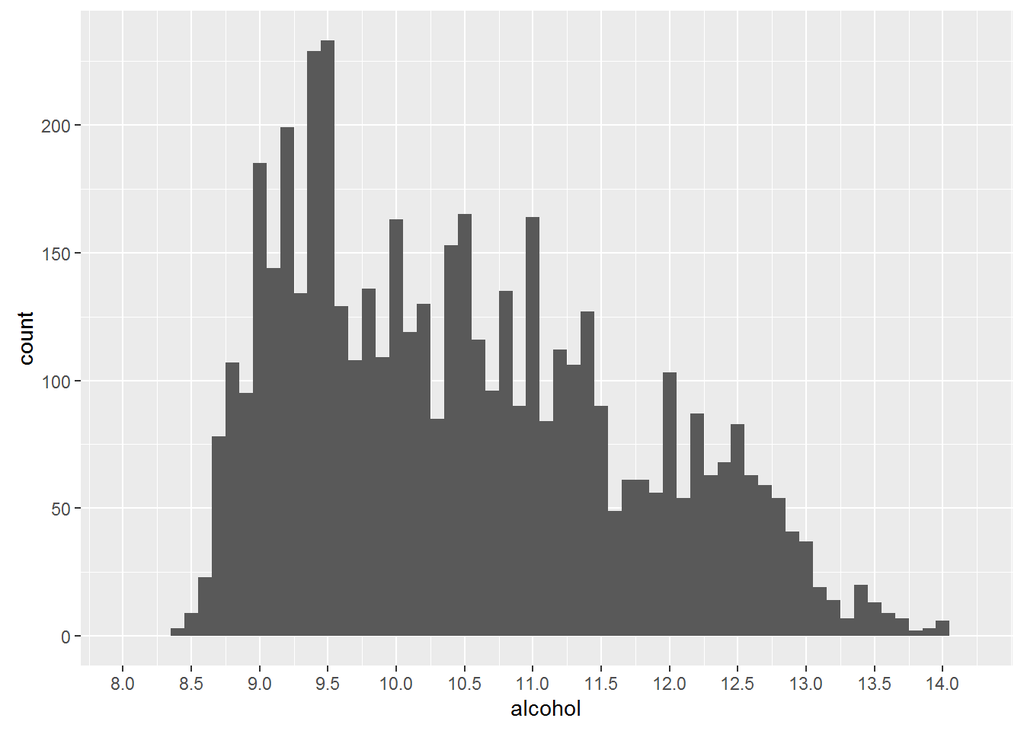

```
##    Min. 1st Qu.  Median    Mean 3rd Qu.    Max.
##    8.00    9.50   10.40   10.51   11.40   14.20
```

The distribution is skewed to right, but it is not a sharp decline (as happens with residual sugar), it is rather a more slight one. The peak is around 9.5, and there are not blatant outliers.

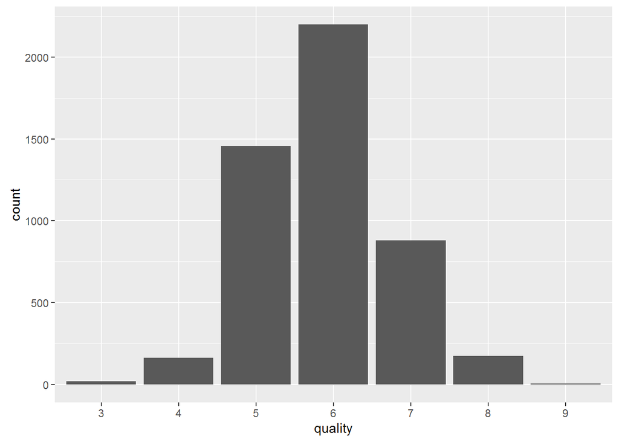

Six is clearly the most frequent quality. In spite of the range goes from 0 to 10, there are not wines qualified with 0, 1, 2 or 10.

# Univariate Analysis

There are 4898 white wines in the dataset with 12 features. The quality variable was converted from number into an ordered factor variable, with the following order:

(worst) ——> (best) Quality: 0,1,2,3,4,5,6,7,8,9,10

Other observations:

Quality and alcohol seems to be the most relevant features of the dataset. My goal is to determine which features influentiate the quality of the white wines. After analysing these univariate plots, I believe that the quality of the wine is mainly influenced by the alcolhol.

I kept all the variables of the original dataset, and only changed the quality variable, which was converted from number to ordered factor variable.

The explored distribution mainly tend to be normal, many of them right skewed and with multiple outliers. What caught my attention the most was a peak in citric acid distribution for a particular value close to 0.5 and the sharp decrease in residual sugar.

# Bivariate Plots Section

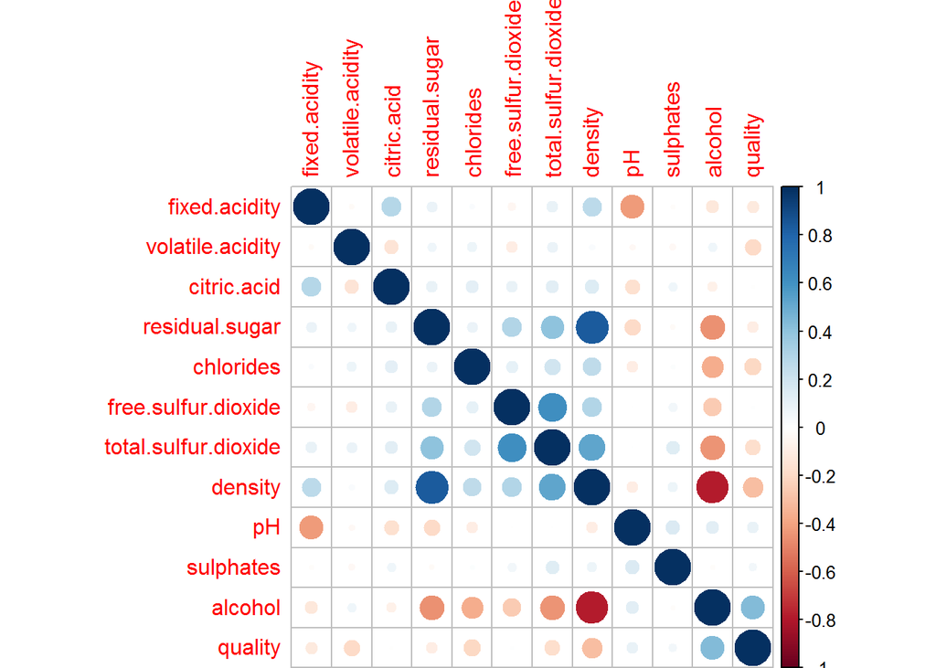

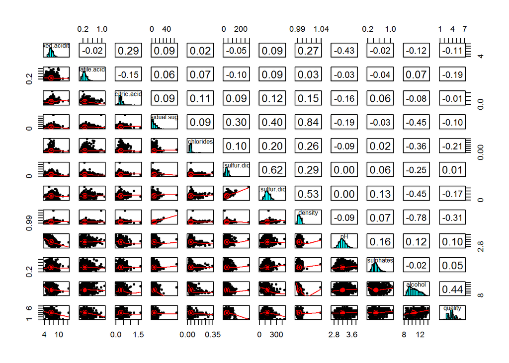

Alcohol is the most correlated with quality, density is also correlated with it but less than alcohol. Total sulfur dioxide, residual sugar and chlorides do not seem to be high correlated with quality, but they are strongly correlated with alcohol (mainly the first two ones). And there is also a strong correlation between density and residual sugar, and both are strong correlated with alcohol. I would pay special attention at plots related to quality, alcohol and some of the previous mentioned variables.

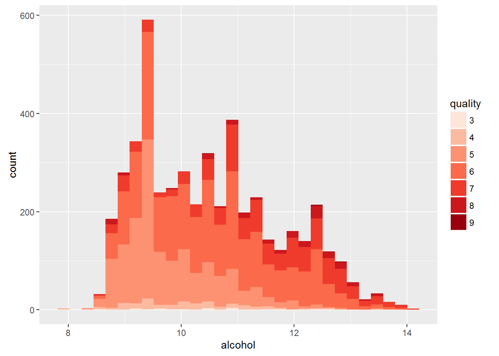

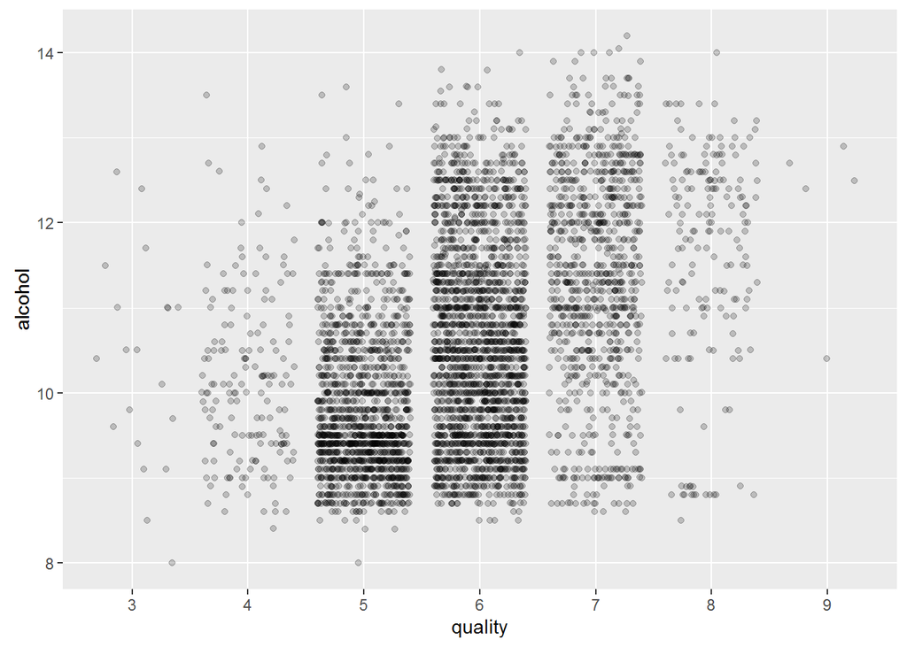

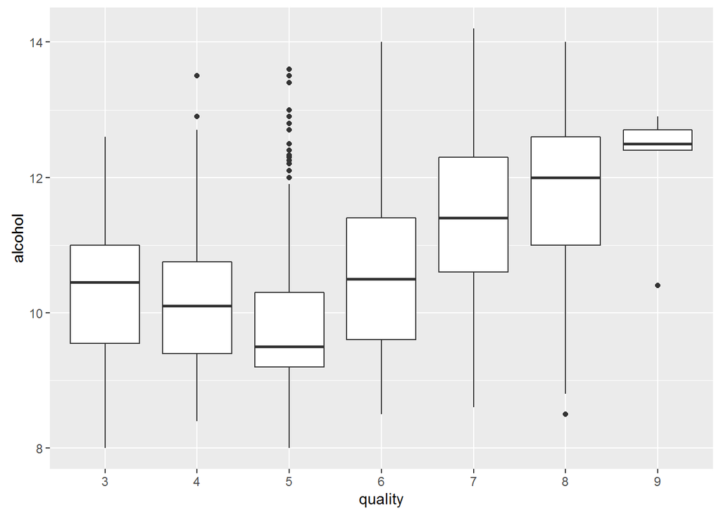

```
## wws$quality: 3
##    Min. 1st Qu.  Median    Mean 3rd Qu.    Max.
##    8.00    9.55   10.45   10.34   11.00   12.60
## --------------------------------------------------------
## wws$quality: 4
##    Min. 1st Qu.  Median    Mean 3rd Qu.    Max.
##    8.40    9.40   10.10   10.15   10.75   13.50
## --------------------------------------------------------
## wws$quality: 5
##    Min. 1st Qu.  Median    Mean 3rd Qu.    Max.
##   8.000   9.200   9.500   9.809  10.300  13.600
## --------------------------------------------------------
## wws$quality: 6
##    Min. 1st Qu.  Median    Mean 3rd Qu.    Max.
##    8.50    9.60   10.50   10.58   11.40   14.00
## --------------------------------------------------------
## wws$quality: 7
##    Min. 1st Qu.  Median    Mean 3rd Qu.    Max.
##    8.60   10.60   11.40   11.37   12.30   14.20
## --------------------------------------------------------
## wws$quality: 8
##    Min. 1st Qu.  Median    Mean 3rd Qu.    Max.
##    8.50   11.00   12.00   11.64   12.60   14.00
## --------------------------------------------------------
## wws$quality: 9
##    Min. 1st Qu.  Median    Mean 3rd Qu.    Max.
##   10.40   12.40   12.50   12.18   12.70   12.90
```

The plots confirm the high correlation between alcohol and quality. The relationship doesn’t seem to be linear. From three to five the median alcohol decrease and it increases from there on. There are very few wines under nine category, and one of them is an outlier.

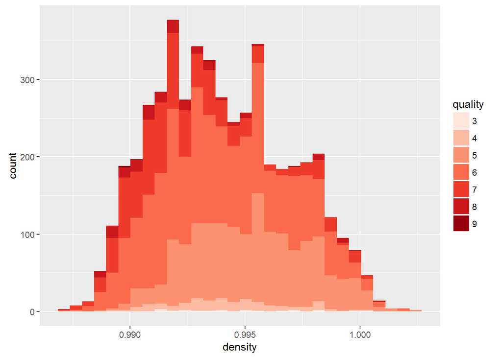

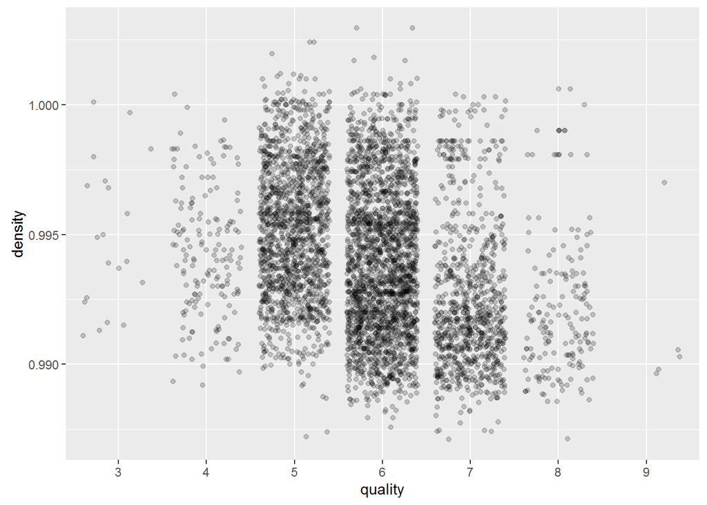

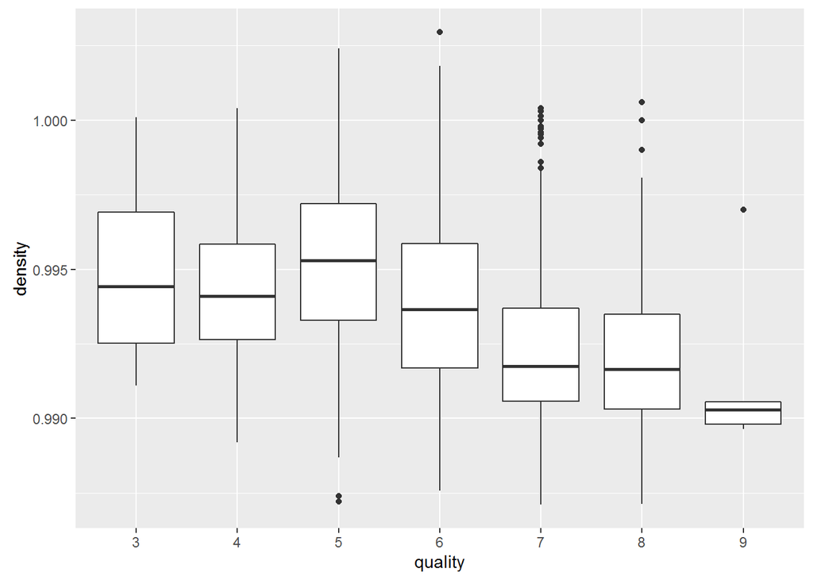

```
## wws$quality: 3
##    Min. 1st Qu.  Median    Mean 3rd Qu.    Max.
##  0.9911  0.9925  0.9944  0.9949  0.9969  1.0000
## --------------------------------------------------------
## wws$quality: 4
##    Min. 1st Qu.  Median    Mean 3rd Qu.    Max.
##  0.9892  0.9926  0.9941  0.9943  0.9958  1.0000
## --------------------------------------------------------
## wws$quality: 5
##    Min. 1st Qu.  Median    Mean 3rd Qu.    Max.
##  0.9872  0.9933  0.9953  0.9953  0.9972  1.0020
## --------------------------------------------------------
## wws$quality: 6
##    Min. 1st Qu.  Median    Mean 3rd Qu.    Max.
##  0.9876  0.9917  0.9937  0.9940  0.9959  1.0390
## --------------------------------------------------------
## wws$quality: 7
##    Min. 1st Qu.  Median    Mean 3rd Qu.    Max.
##  0.9871  0.9906  0.9918  0.9925  0.9937  1.0000
## --------------------------------------------------------
## wws$quality: 8
##    Min. 1st Qu.  Median    Mean 3rd Qu.    Max.
##  0.9871  0.9903  0.9916  0.9922  0.9935  1.0010
## --------------------------------------------------------
## wws$quality: 9
##    Min. 1st Qu.  Median    Mean 3rd Qu.    Max.
##  0.9896  0.9898  0.9903  0.9915  0.9906  0.9970
```

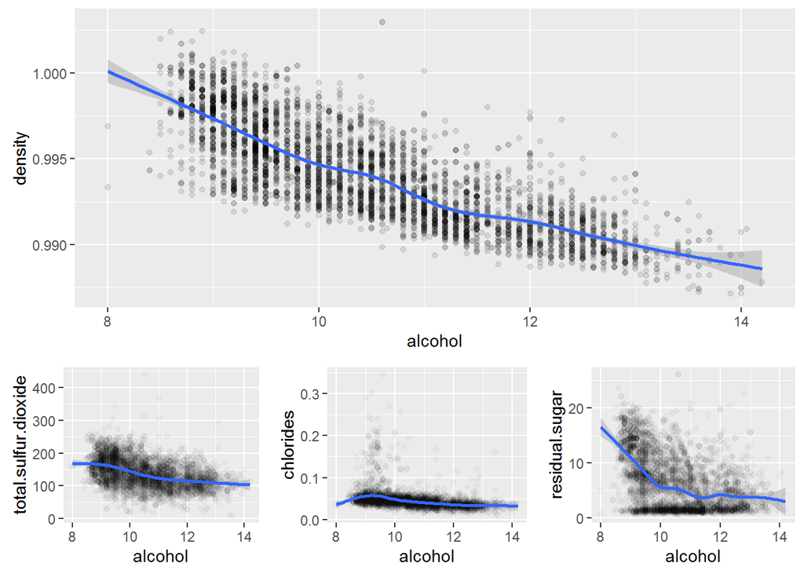

Across this serie of alcohol plots a negative correlation can be observed, being the most notorious the one related to density. The total sulfur dioxide and chlorides plots show a slight slope, whereas that in the residual.sugar plot has a non linear relation where two main groups with highest concentration of wines can be observed, one at the top left corner and the other one at the botom.

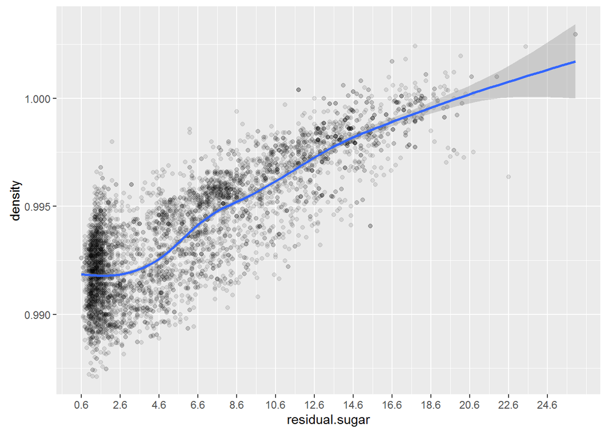

This plot shows a high correlation, and there is a clear concentration of wines around 1.6 of residual.sugar

# Bivariate Analysis

As expected, quality is high correlated with alcohol, and also with density to a lesser extent.

Relationship between alcohol and quality doesn’t seem to be linear in general, but from quality six on it does. Something similar happens with density, but to a lesser extent and it has an opposing relationship to the one expressed by alcohol.

On the other hand, alcohol is clearly negative correlated with four variables being density the most strong, followed by residual sugar, total sulfur dioxide and chlorides. From the plots related to these variables, the most striking was the one related to residual sugar, because unlike the others plots it shows an irregular distribution.

Residual sugar and density are the highest correlated variables in the dataset.

# Multivariate Plots Section

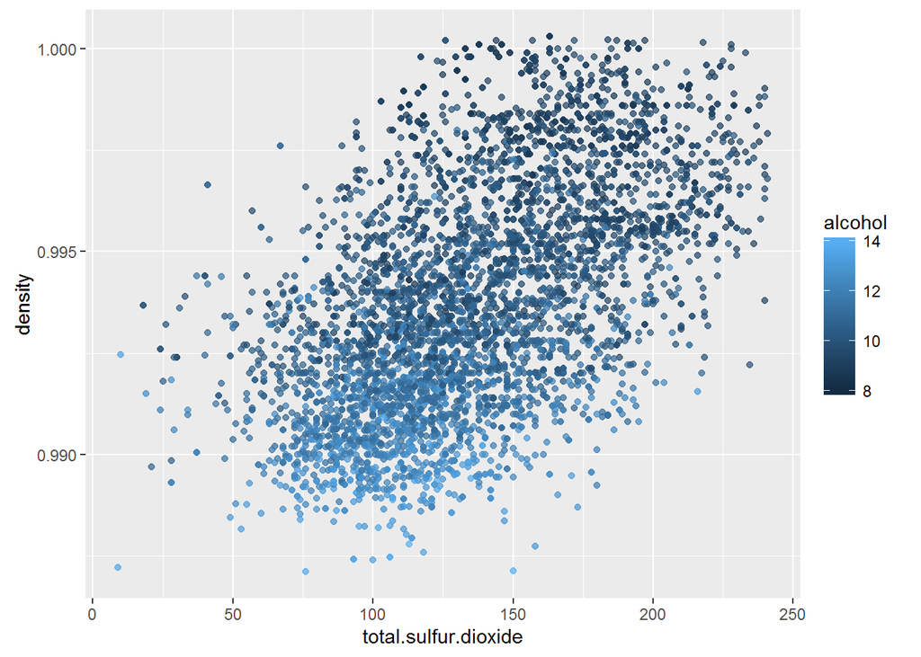

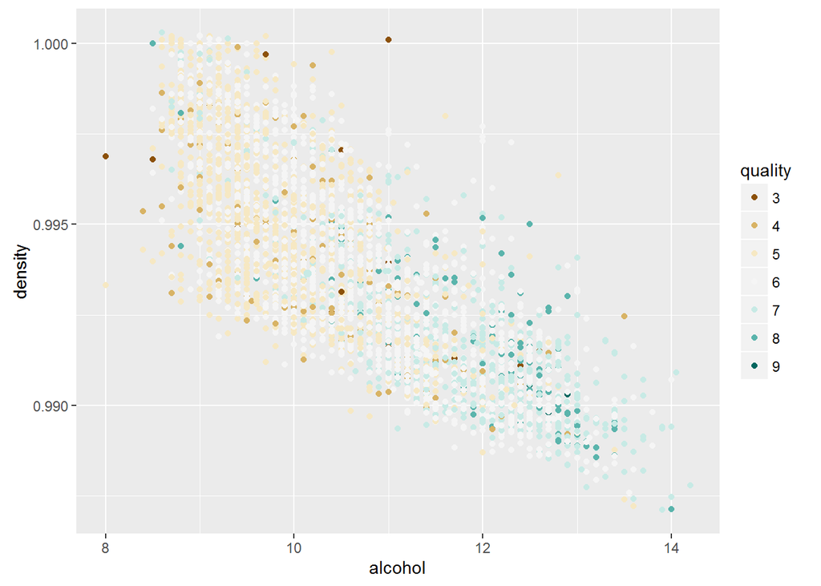

Given that Alcohol and Density are the most correlated variable with Quality, I expected this plot to show a significant relation between them. But I didn’t get the expected result, the only strong relation in this plot is the one between alcohol and quality.

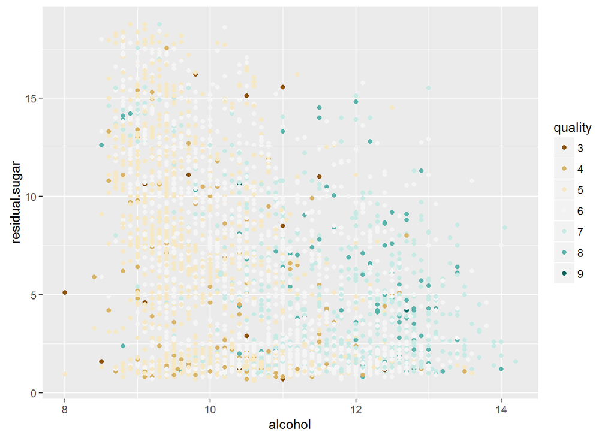

In spite of the correlation value is practically zero, I had some reasons to believe that there could be some correlation between these three variables, due to the fact that there is a strong correation between residual.sugar and alcohol and with alcohol and quality. But this plot only seems to show a strong correlation between alcohol and quality.

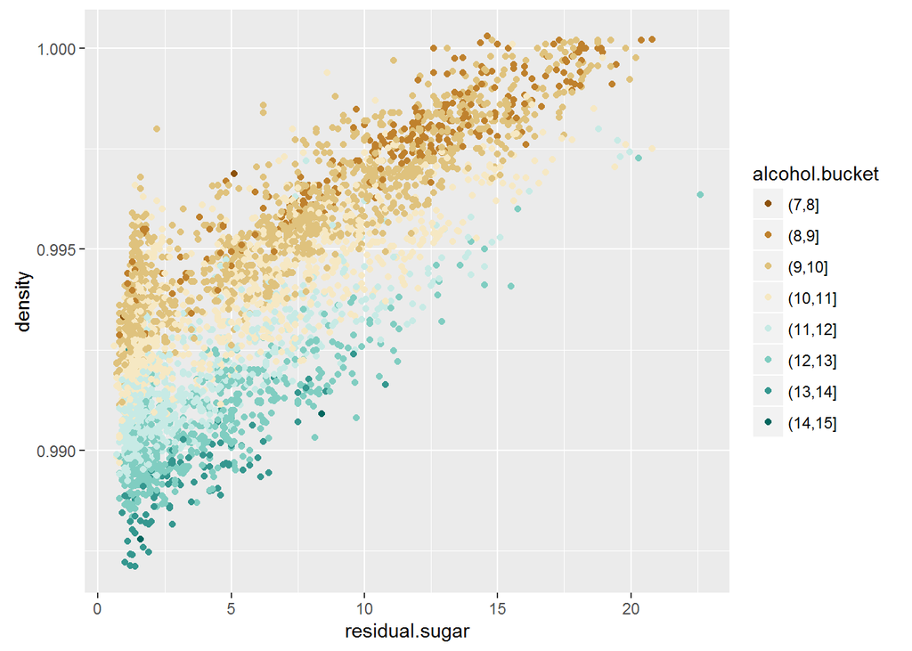

This plots seems to express a short trend between density, residual sugar and alcohol. The alcohol seems to be placed in three strips approximately. The lower one shows the biggest alcohol level, the middle one an intermediate level, and the upper one the lowest level.

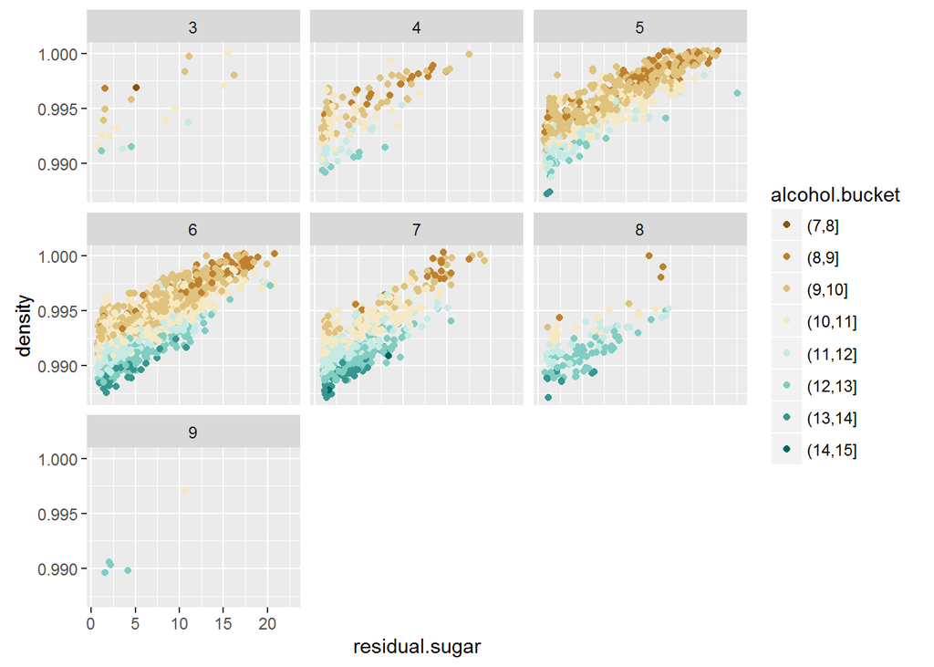

There is a clear quality trend across this plots. As the quality increases it is notorious how it moves from upper strip to lower one.

```
##
## Calls:
## m1: lm(formula = quality ~ alcohol, data = ww)
## m2: lm(formula = quality ~ alcohol + density, data = ww)
## m3: lm(formula = quality ~ alcohol + density + residual.sugar, data = ww)
## m4: lm(formula = quality ~ alcohol + density + residual.sugar + volatile.acidity,
##     data = ww)
##
## ===================================================================
##                        m1          m2          m3          m4
## -------------------------------------------------------------------
##   (Intercept)        2.582***  -22.492***   90.313***   74.225***
##                     (0.098)     (6.165)    (12.374)    (11.977)
##   alcohol            0.313***    0.360***    0.246***    0.286***
##                     (0.009)     (0.015)     (0.018)     (0.018)
##   density                       24.728***  -87.886***  -71.546***
##                                 (6.079)    (12.317)    (11.923)
##   residual.sugar                             0.053***    0.052***
##                                             (0.005)     (0.005)
##   volatile.acidity                                      -2.059***
##                                                         (0.109)
## -------------------------------------------------------------------
##   R-squared             0.190      0.192       0.210       0.264
##   adj. R-squared        0.190      0.192       0.210       0.263
##   sigma                 0.797      0.796       0.787       0.760
##   F                  1146.395    583.290     434.085     438.646
##   p                     0.000      0.000       0.000       0.000
##   Log-likelihood    -5839.391  -5831.127   -5776.812   -5604.126
##   Deviance           3112.257   3101.773    3033.737    2827.187
##   AIC               11684.782  11670.255   11563.624   11220.251
##   BIC               11704.272  11696.241   11596.107   11259.231
##   N                  4898       4898        4898        4898
## ===================================================================
```

# Multivariate Analysis

In general the correlations that shows the correlation matrix can be sustained across the plots of this section. Anyway, the plot of density, residual sugar and alcohol bucket shows some trend which cannot be deducted from the correlation matrix itself. This particular plot shows how the many alcohol levels tend to be grouped along well defined strips. As this caught my attention, y decided to create a linear model including this variables among others.

Apart from the alcohol level strips I mentioned above, it surprised me adding the volatile.acidity variable in the linear model. I didn’t expected that the r-squared increases much more than with density.

I created the model to predict de withe wine’s quality. The prediction accuracy is poor (the r-squared is lower than 0.3). It was clear from the begining that alcohol was going to have the biggest influence in the model. But it wasn’t so clear that density was going to have fewer influence than volatile acidity. I think this is due to the fact that density is highly correlated with alcohol, and it doesn’t provide any further information. Which is different from volatile.acidity which is almost not correlated with alcohol but anyway has a correlation with quality, even though it is not a strong one.

# Final Plots and Summary

### Plot One

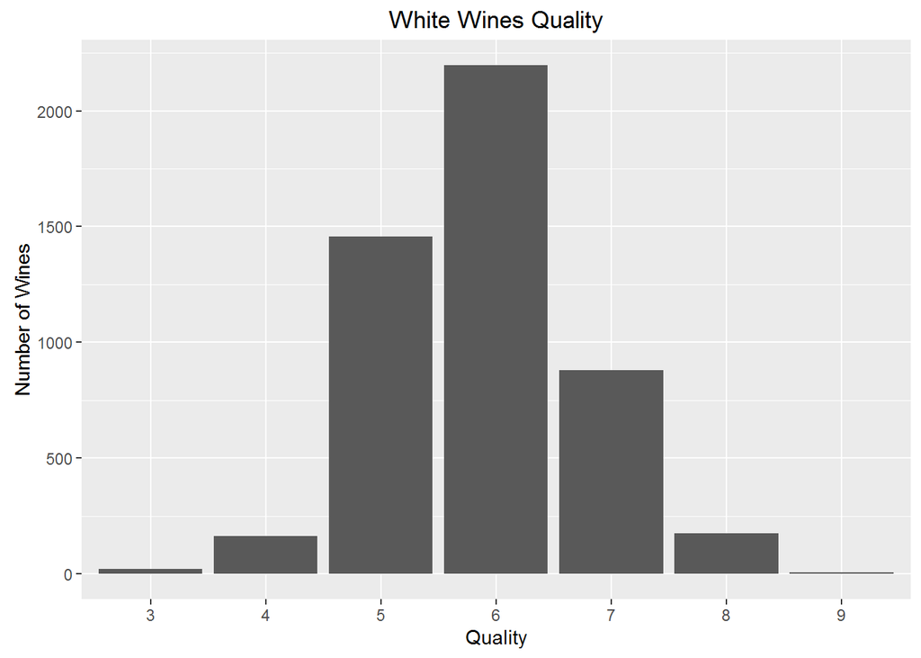

### Description One

Quality seems to be normally distribuited, with a clear peak at quality six. Qualities 0,1,2 and 10 are not included, probably because the experts decided not to qualify a meassure less than three.

### Plot Two

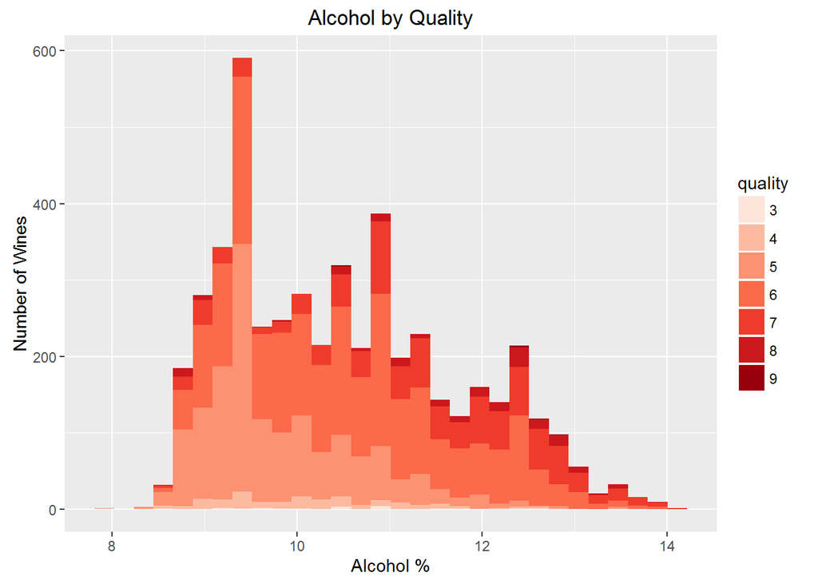

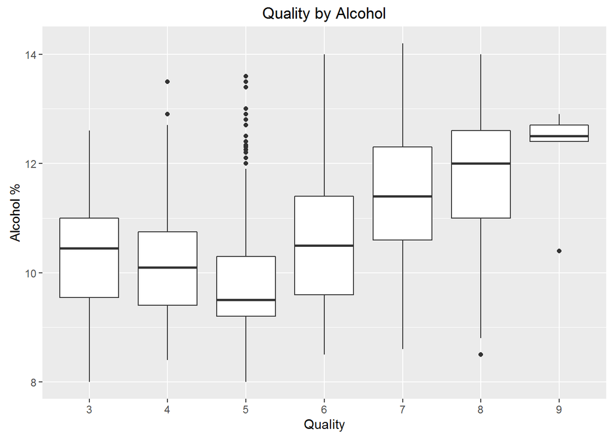

### Description Two

The correlation of quality with alcohol is not linear, but clearly the quality increases as the alcohol level increases from quality six.

### Plot Three

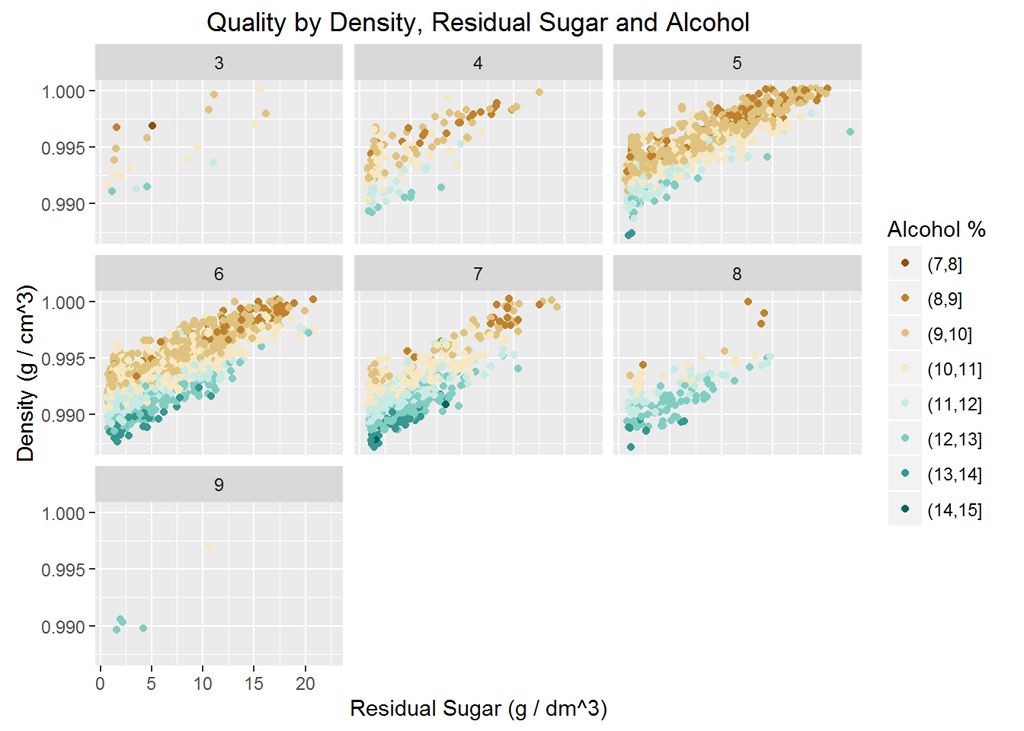

### Description Three

In this plot a noticeable relation between quality and three other variables can be observed. The alcohol level is well defined into three main strips related to density and residual sugar. And it can be noticed how the strips tends to appear and disappear from worst to best quality.

# Reflection

This dataset contains information for about 4898 white wines. Twelve variables are provided for each wine. Eleven of them describes the quimical composition, and the last one describe the quality. Given that information, I explored the quality across the provided variables.

The correlation between quality and alcohol was the most notorious from the beginning, and beside this correlation I expected quality to be highly correlated with density. Having this in my mind the linear model took me by surprised, alcohol was indeed the most influential, but density barely had some influence. Moreover, what caught my attention the most was the influence of Volatile Acidity variable in the linear model, which didn’t seem to has a great influence at first glance, but it was the most relevant variable after alcohol. Anyway after considering it for a while, I came up to the conclusion that unlike density, it wasn’t strongly correlated to alcohol, therefore the influence it has on the quality wasn’t tight to other variable.

In addition to the findings related to the linear model, I found a clear pattern in alcohol, density and residual sugar plot. The alcohol is placed on strips according to its graduation (which was split into buckets), and when I generated plots faceted by quality, it was clear how wines moved from top to bottom strips across the different qualities.

As the current model didn’t predict the quality very well (r-squared=0.264), in a future work I would explore the Volatile Acidity in more detail and consider the alcohol strips pattern to try another model to fit better the data.